# 2020 Canadian employment income by group

2024-11-18

## How does my salary compare?

The [2020 Canadian employment income by group](https://sagarana.shinyapps.io/income_percentile/) shiny app uses public microdata from Statistics Canada to:

- show distribution of employment income by citizenship, gender, home ownership, and first language
- calculate the percentile of an income entered by the user, showing differences across groups

## About the data

[2021 Census of Canada public microdata](https://hdl.handle.net/11272.1/AB2/1WTDOP) provides 2020 income data for a sample of nearly 1 million people in Canada.

For meaningful salary comparisons the app uses the *employment income* variable, `EmpIn`.

For reproducibility, when uncommented this code will download, unzip, and load the data:

```r
#download.file("https://abacus.library.ubc.ca/api/access/datafile/
#:persistentId?persistentId=hdl:11272.1/AB2/1WTDOP/HIYEIA",
#"CENSUS_2021.zip", mode="wb")
#unzip("CENSUS_2021.zip")

data2021 <- read_sav("cen_ind_2021_pumf_v2.sav")
```

## Preparing the data

The [2021 Census Individuals PUMF User Guide](https://hdl.handle.net/11272.1/AB2/1WTDOP/EV7NLM) documents each variable and informs data preparation.

Only a handful of variables are used in the app, and the data is limited to ages 18-69 (about 530K rows). Here’s a sample table from the prepared dataset.

```r
table(census_subset_2021$Citizen, census_subset_2021$Gender)
```

```
##
##                                       Woman+   Man+
##   Canadian citizens by birth          185014 193327
##   Canadian citizens by naturalization  48730  48914
##   Not a Canadian citizen               25079  28564
```

**Note:** the user guide explains that “individuals in the category ‘non-binary persons’ are distributed into the other two gender categories and are denoted by the ‘+’ symbol.”

Here is app output for a reference salary of CAD $60,000 (dotted line) grouped by home ownership.

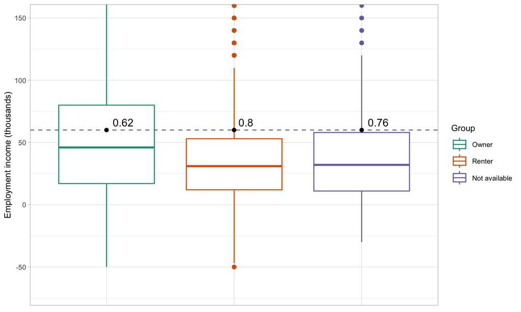

In 2020 CAD $60,000 was the 80th percentile among renters.